# Time Series Anaysis on FDIC SDI Dataset

#### This report analyzes FDIC SDI data from 2007 - 2019, focusing on Net Asset variable. ARIMA and ARIMAX model have been applied for forward forecasting, with detrending and de-seasonalizing during pre-precessing to achieve stationary data status.

##### ----- Fortuna Zhang, June 2020

## MS Azure Set up

```python
import logging

import numpy as np
import pandas as pd
import matplotlib.pyplot as plt
from pandas.plotting import autocorrelation_plot
import matplotlib.pyplot as plt
import matplotlib as mpl
import seaborn as sns
from statsmodels.tsa.stattools import adfuller, kpss
from scipy import signal
from statsmodels.tsa.seasonal import seasonal_decompose

from azureml.core.workspace import Workspace
from azureml.core.experiment import Experiment
import azureml.dataprep as dprep
from azureml.automl.core.featurization import FeaturizationConfig
from azureml.train.automl import AutoMLConfig
from azureml.core.dataset import Dataset

import warnings
warnings.filterwarnings('ignore')
```

```python
#check the version of azureml.core
print("the version of azureml is ", azureml.core.VERSION)
```

```
the version of azureml is  1.6.0
```

## Obtain workspace information

```python
ws = Workspace.from_config()

#your experiment_name
experiment_name = 'test'
experiment = Experiment(ws,experiment_name)

output = {}
output['Subscription ID'] = ws.subscription_id
output['Workspace Name'] = ws.name
output['Resource Group'] = ws.resource_group
output['Location'] = ws.location
output['Experiment Name'] = experiment.name
pd.set_option('display.max_colwidth', -1)
outputDf = pd.DataFrame(data = output, index = [''])
outputDf.T
```

| Subscription ID | de1faa6a-bb72-4633-8d66-b148cb10deb9 |
| --- | --- |
| Workspace Name | Fortuna |
| Resource Group | Main |
| Location | westcentralus |
| Experiment Name | test |

## Create an AmlCompute as compute target

```python
from azureml.core.compute import ComputeTarget, AmlCompute
from azureml.core.compute_target import ComputeTargetException

#name of the cluster
cluster_name = 'FortunaCom'

try:
    compute_target = ComputeTarget(workspace=ws,name=cluster_name)
    print("Found Compute, use it!")
except ComputeTargetException:
    compute_config = AmlCompute.provisioning_configuration(vm_size='STANDARD_D2_V2',max_nodes=4)
    compute_target =  ComputeTarget.create(ws,cluster_name,compute_config)

compute_target.wait_for_completion(show_output=True)
```

```
Found Compute, use it!

Running
```

## Load Data

```python
import pandas as pd

from azureml.core import Workspace, Dataset

subscription_id = 'de1faa6a-bb72-4633-8d66-b148cb10deb9' # compute id
resource_group = 'Main'
workspace_name = 'Fortuna'

workspace = Workspace(subscription_id, resource_group, workspace_name)

dataset = Dataset.get_by_name(workspace, name='SDI_test')
df = dataset.to_pandas_dataframe()
```

```python
# convert repdte from string to datetime for time series analysis
df['time'] = pd.to_datetime(df['repdte'], format='%Y%m%d')
df['year'] = pd.DatetimeIndex(df['time']).year
```

```python
df.columns
df.head()
```

|  | repdte | offdom | specgrp | numemp | asset | liab | dep | eeffr | netasset | time | year |
| --- | --- | --- | --- | --- | --- | --- | --- | --- | --- | --- | --- |
| 0 | 2014-12-31 | 3 | 4 | 34 | 191843 | 169954 | 165710 | 80.466776 | 21889 | 2014-12-31 | 2014 |
| 1 | 2015-03-31 | 3 | 4 | 33 | 194321 | 172312 | 167972 | 81.610577 | 22009 | 2015-03-31 | 2015 |
| 2 | 2015-06-30 | 3 | 4 | 31 | 192823 | 170609 | 166257 | 80.308422 | 22214 | 2015-06-30 | 2015 |
| 3 | 2015-09-30 | 6 | 4 | 47 | 318444 | 281674 | 275401 | 93.231202 | 36770 | 2015-09-30 | 2015 |
| 4 | 2015-12-31 | 6 | 4 | 50 | 316293 | 278942 | 271590 | 82.871972 | 37351 | 2015-12-31 | 2015 |

```python
# # we only explore the community bank net asset
# cb_df = df[df['CB']==1]
# cb_df['NetAsset'] = cb_df['Asset']**(1-cb_df['LoanToAsset'])
# cb_df.head()
```

```python
df.isnull().sum()
```

```
repdte      0
offdom      0
specgrp     0
numemp      0
asset       0
liab        0
dep         0
eeffr       0
netasset    0
time        0
year        0
dtype: int64
```

## Time Series Analysis

### Steps:

```
1. Visualization Exploration: Trend line & Box plot (Economic cycle)
2. Stationary Test (ADF & KPSS)
3. Detrending (Substract best fit & Multiplicative Decompose)
4. Deseasonalizing
5. Autocorrelation & Partial Autocorrelation
6. ARIMA Model Prediction
7. Exponential Smoothing Prediction
8. GARCH Model Prediction
9. Trend Scanning Labelling
10. ARIMAX Model Prediction
```

### Visualization Exploration

#### Trend lines

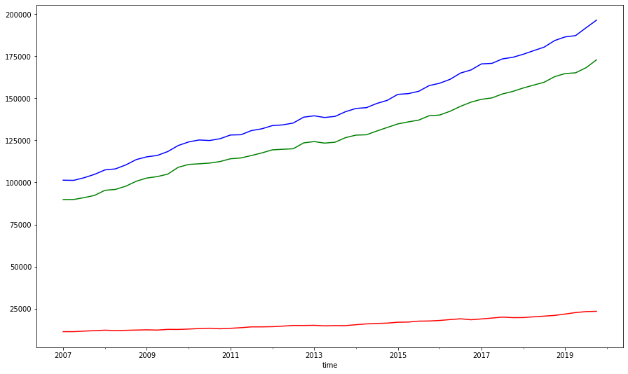

```python
# Asset and Loan Average value Changes
dategroup = df.groupby('time').median()
dategroup.index= pd.to_datetime(dategroup.index, format='%Y%m%d')

fig, ax = plt.subplots(figsize=(15,9))
# dategroup['netasset'].plot(ax=ax[0],color='red')
# dategroup['asset'].plot(ax=ax[1],color='blue')
# dategroup['liab'].plot(ax=ax[2],color='green')
# ax[0].set_title('Net Asset', fontsize=10);
# ax[1].set_title('Asset', fontsize=10)
# ax[2].set_title('Liability', fontsize=10)

dategroup['netasset'].plot(color='red')
dategroup['asset'].plot(color='blue')
dategroup['liab'].plot(color='green')
```

#### Economic Cylce & Net Asset

```python
# fig, ax = plt.subplots(3,figsize=(15,15), sharex=False)
# # 2001 recession caused by stock market crash, high-interest rates
# sns.boxplot(data=dategroup[dategroup['year'] <2010] , x='year', y='netasset', ax=ax[0])
# # Derivatives created housing bubble in 2006
# sns.boxplot(data=dategroup[dategroup['year'].between(2010,2015)] , x='year', y='netasset', ax=ax[1])
# # Subprime mortgage crisis, 2008 financial crisis, the Great Recession
# sns.boxplot(data=dategroup[dategroup['year']>2015] , x='year', y='netasset', ax=ax[2])
# # ax.set_ylabel('Value')
# # ax.set_title('Net Asset')
# ax[0].set_title('1993 Deficit Reduction Act & 2000 Dot-com bubble', fontsize=10);
# ax[1].set_title('2007 Subprime mortgage crisis', fontsize=10)
# ax[2].set_title('2008 Financial crisis & 2009 American Recovery and Reinvestment Act', fontsize=10)
# # Remove the automatic x-axis label from all but the bottom subplot
# ax[0].set_xlabel('')
# ax[1].set_xlabel('')
```

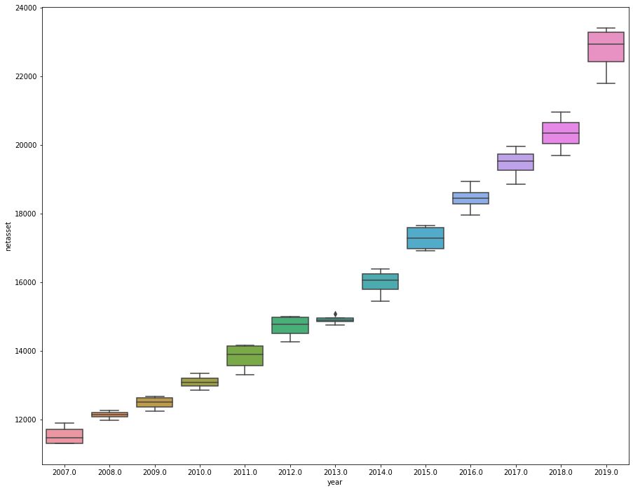

```python
fig, ax = plt.subplots(figsize=(15,12), sharex=False)
sns.boxplot(data=dategroup , x='year', y='netasset')
```

#### Granger Causal Test

To test if time lag can help to predict net asset or not

```python
import statsmodels.api as sm
sm.tsa.stattools.grangercausalitytests(dategroup[['netasset', 'year']],maxlag = 16).values
```

```
Granger Causality
number of lags (no zero) 1
ssr based F test:         F=1.2309  , p=0.2728  , df_denom=48, df_num=1
ssr based chi2 test:   chi2=1.3078  , p=0.2528  , df=1
likelihood ratio test: chi2=1.2913  , p=0.2558  , df=1
parameter F test:         F=1.2309  , p=0.2728  , df_denom=48, df_num=1

Granger Causality
number of lags (no zero) 2
ssr based F test:         F=0.5187  , p=0.5988  , df_denom=45, df_num=2
ssr based chi2 test:   chi2=1.1528  , p=0.5619  , df=2
likelihood ratio test: chi2=1.1397  , p=0.5656  , df=2
parameter F test:         F=0.5187  , p=0.5988  , df_denom=45, df_num=2

Granger Causality
number of lags (no zero) 3
ssr based F test:         F=1.8220  , p=0.1578  , df_denom=42, df_num=3
ssr based chi2 test:   chi2=6.3771  , p=0.0946  , df=3
likelihood ratio test: chi2=5.9949  , p=0.1119  , df=3
parameter F test:         F=1.8220  , p=0.1578  , df_denom=42, df_num=3

Granger Causality
number of lags (no zero) 4
ssr based F test:         F=6.2488  , p=0.0006  , df_denom=39, df_num=4
ssr based chi2 test:   chi2=30.7634 , p=0.0000  , df=4
likelihood ratio test: chi2=23.7719 , p=0.0001  , df=4
parameter F test:         F=6.2488  , p=0.0006  , df_denom=39, df_num=4

Granger Causality
number of lags (no zero) 5
ssr based F test:         F=3.9588  , p=0.0056  , df_denom=37, df_num=5
ssr based chi2 test:   chi2=25.1438 , p=0.0001  , df=5
likelihood ratio test: chi2=20.1402 , p=0.0012  , df=5
parameter F test:         F=4.7535  , p=0.0019  , df_denom=37, df_num=5

Granger Causality
number of lags (no zero) 6
ssr based F test:         F=2.2625  , p=0.0598  , df_denom=35, df_num=6
ssr based chi2 test:   chi2=17.8415 , p=0.0066  , df=6
likelihood ratio test: chi2=15.0771 , p=0.0197  , df=6
```

[output cut: 56 more lines]

```
parameter F test:         F=3.5607  , p=0.0193  , df_denom=19, df_num=5

Granger Causality
number of lags (no zero) 15
ssr based F test:         F=0.6365  , p=0.8077  , df_denom=17, df_num=15
ssr based chi2 test:   chi2=20.7787 , p=0.1440  , df=15
likelihood ratio test: chi2=16.4910 , p=0.3502  , df=15
parameter F test:         F=3.7013  , p=0.0189  , df_denom=17, df_num=5

Granger Causality
number of lags (no zero) 16
ssr based F test:         F=0.3931  , p=0.9633  , df_denom=15, df_num=16
ssr based chi2 test:   chi2=15.0944 , p=0.5177  , df=16
likelihood ratio test: chi2=12.6056 , p=0.7013  , df=16
parameter F test:         F=2.8340  , p=0.0537  , df_denom=15, df_num=5
```

```
<function dict.values>
```

```python
# 2019 as testset, the other years as traning set
# dategroup = dategroup[dategroup['year']!=2019]
```

### Stationarity Test - Unit Root Tests

```python
#  ADF Test
print('\nNetAsset: Stationarity test 1')
result = adfuller(dategroup.netasset.values, autolag='AIC')
print(f'ADF Statistic: {result[0]}')
print(f'p-value: {result[1]}')
for key, value in result[4].items():
    print('Critial Values:')
    print(f'   {key}, {value}')


# KPSS Test
result = kpss(dategroup.netasset.values, regression='c')
print('\nKPSS Statistic: %f' % result[0])
print('p-value: %f' % result[1])
for key, value in result[3].items():
    print('Critial Values:')
    print(f'   {key}, {value}')
```

```
NetAsset: Stationarity test 1
ADF Statistic: 2.9139950799764422
p-value: 1.0
Critial Values:
   1%, -3.596635636000432
Critial Values:
   5%, -2.933297331821618
Critial Values:
   10%, -2.6049909750566895

KPSS Statistic: 0.556552
p-value: 0.028930
Critial Values:
   10%, 0.347
Critial Values:
   5%, 0.463
Critial Values:
   2.5%, 0.574
Critial Values:
   1%, 0.739
```

For NetAsset:  
ADF test: Since p-value is larger than 0.1, we cannot reject the null hypothesis that there is a unit root/data is non-stationary.  
KPSS test: Since p-value is less than 0.05, we reject the null hypothesis that the data is stationary.  
Both tests indicate the original Net Asset time-series data is non-stationary.

### Detrend - two methods

#### Method 1: Subtract the line of best fit

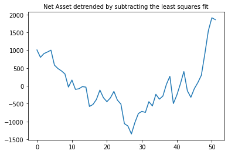

```python
# Method 1 - Using scipy: Subtract the line of best fit
from scipy import signal
detrended1 = signal.detrend(dategroup.netasset.values)

f = plt.figure()
plt.plot(detrended1)
plt.title('Net Asset detrended by subtracting the least squares fit', fontsize=10)
```

After detrending, Net Asset time-series data has concave upward, trend component has succesfully been removed. There may be a parabola in the residuals, suggesting that perhaps a polynomial fit may have done a better job.

```python
# ADF Test
print('Net Asset: Stationarity test 2')
result = adfuller(detrended1, autolag='AIC')
print(f'ADF Statistic: {result[0]}')
print(f'p-value: {result[1]}')
for key, value in result[4].items():
    print('Critial Values:')
    print(f'   {key}, {value}')

# KPSS Test
result = kpss(detrended1, regression='c')
print('\nKPSS Statistic: %f' % result[0])
print('p-value: %f' % result[1])
for key, value in result[3].items():
    print('Critial Values:')
    print(f'   {key}, {value}')
```

```
Net Asset: Stationarity test 2
ADF Statistic: -0.6259915379774629
p-value: 0.865000191267701
Critial Values:
   1%, -3.5656240522121956
Critial Values:
   5%, -2.920142229157715
Critial Values:
   10%, -2.598014675124952

KPSS Statistic: 0.167171
p-value: 0.100000
Critial Values:
   10%, 0.347
Critial Values:
   5%, 0.463
Critial Values:
   2.5%, 0.574
Critial Values:
   1%, 0.739
```

For Net Asset:  
ADF test: Since p-value is larger than 0.1, we cannot reject the null hypothesis that there is a unit root/data is non-stationary.  
KPSS test: Since p-value is equal to 0.1, we cannot reject the null hypothesis at 10% level that the data is stationary. This shows that detrending imporves stationarity of Net Asset data. However, substracting best fit result is not so satisfying to achieve stationary condition.

#### Method2: Multiplicative or Additive decompose (compare)

Triple Components

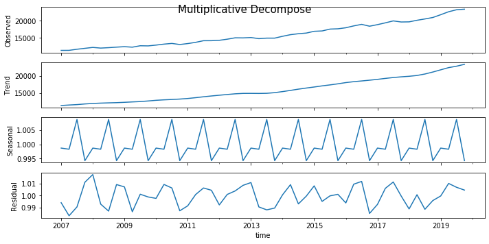

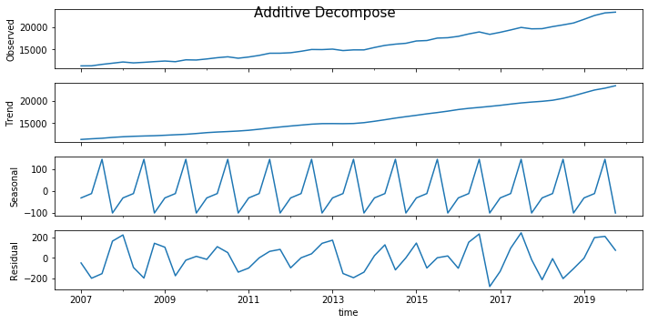

```python
from statsmodels.tsa.seasonal import seasonal_decompose
from dateutil.parser import parse

# Multiplicative Decomposition
result_mul = seasonal_decompose(dategroup.netasset, model='multiplicative', extrapolate_trend='freq')

# Additive Decomposition
result_add = seasonal_decompose(dategroup.netasset, model='additive', extrapolate_trend='freq')

# Plot
fig = plt.figure()
fig.set_figheight(20) # optional setting the height of the image
fig.set_figwidth(20) # optional setting the width of the image

# fig, ax = plt.subplots(ncols=2, sharex=True, sharey=True)
plt.rcParams.update({'figure.figsize': (10,5)})
result_mul.plot().suptitle('Multiplicative Decompose', fontsize=15)

result_add.plot().suptitle('Additive Decompose', fontsize=15)
plt.show()
```

For Net Asset data, we choose Multiplicative Decompose method because the magnitude of the seasonal pattern in the data depends on the magnitude of the data, and residuals are less vary with the level of the time series compared to additive method.

```python
# Extract the Components ----
# Actual Values = Product of (Seasonal * Trend * Resid)
df_reconstructed = pd.concat([result_mul.seasonal, result_mul.trend, result_mul.resid, result_mul.observed], axis=1)
df_reconstructed.columns = ['season', 'trend', 'resid', 'actual_values']
df_reconstructed.head()
```

| time | season | trend | resid | actual_values |
| --- | --- | --- | --- | --- |
| 2007-03-31 | 0.998689 | 11385.68750 | 0.994041 | 11303.0 |
| 2007-06-30 | 0.998291 | 11530.34375 | 0.983134 | 11316.5 |
| 2007-09-30 | 1.008724 | 11651.75000 | 0.990522 | 11642.0 |
| 2007-12-31 | 0.994296 | 11844.18750 | 1.011113 | 11907.5 |
| 2008-03-31 | 0.998689 | 11985.00000 | 1.017521 | 12179.0 |

Multiplicative Decompose

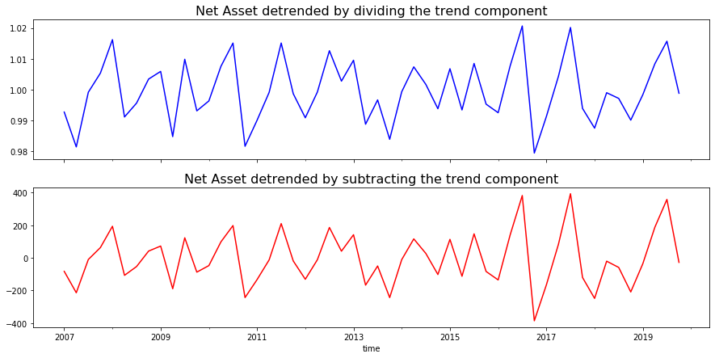

```python
# Method2: Using statmodels: Subtracting the Trend Component.
# https://www.statsmodels.org/dev/generated/statsmodels.tsa.seasonal.seasonal_decompose.html
from statsmodels.tsa.seasonal import seasonal_decompose

fig, ax = plt.subplots(2,figsize=(15,7),sharex=True)


result_mul2 = seasonal_decompose(dategroup.netasset, model='multiplicative', extrapolate_trend='freq')
detrended2 = dategroup.netasset.values / result_mul2.trend
detrended2.plot(ax=ax[0],color='blue')
ax[0].set_title('Net Asset detrended by dividing the trend component', fontsize=16);

result_mul2a = seasonal_decompose(dategroup.netasset, model='additive', extrapolate_trend='freq')
detrended2a = dategroup.netasset.values - result_mul2a.trend
detrended2a.plot(ax=ax[1],color='red')
ax[1].set_title('Net Asset detrended by subtracting the trend component', fontsize=16);
```

```python
# Multiplicative
# ADF Test
print('Net Asset: Stationarity test 3 - Multiplicative')
result = adfuller(detrended2, autolag='AIC')
print(f'ADF Statistic: {result[0]}')
print(f'p-value: {result[1]}')
for key, value in result[4].items():
    print('Critial Values:')
    print(f'   {key}, {value}')

# KPSS Test
result = kpss(detrended2, regression='c')
print('\nKPSS Statistic: %f' % result[0])
print('p-value: %f' % result[1])
for key, value in result[3].items():
    print('Critial Values:')
    print(f'   {key}, {value}')

# Additive
# ADF Test
print('\nNet Asset: Stationarity test 3 - Additive')
result = adfuller(detrended2a, autolag='AIC')
print(f'ADF Statistic: {result[0]}')
print(f'p-value: {result[1]}')
for key, value in result[4].items():
    print('Critial Values:')
    print(f'   {key}, {value}')

# KPSS Test
result = kpss(detrended2a, regression='c')
print('\nKPSS Statistic: %f' % result[0])
print('p-value: %f' % result[1])
for key, value in result[3].items():
    print('Critial Values:')
    print(f'   {key}, {value}')
```

```
Net Asset: Stationarity test 3 - Multiplicative
ADF Statistic: -3.9581253087524217
p-value: 0.0016463700919242892
Critial Values:
   1%, -3.5925042342183704
Critial Values:
   5%, -2.931549768951162
Critial Values:
   10%, -2.60406594375338

KPSS Statistic: 0.224239
p-value: 0.100000
Critial Values:
   10%, 0.347
Critial Values:
   5%, 0.463
Critial Values:
   2.5%, 0.574
Critial Values:
   1%, 0.739

Net Asset: Stationarity test 3 - Additive
ADF Statistic: -3.668123248328614
p-value: 0.004584538135666882
Critial Values:
   1%, -3.5925042342183704
Critial Values:
   5%, -2.931549768951162
Critial Values:
   10%, -2.60406594375338

KPSS Statistic: 0.217612
p-value: 0.100000
Critial Values:
   10%, 0.347
Critial Values:
   5%, 0.463
Critial Values:
   2.5%, 0.574
Critial Values:
   1%, 0.739
```

Multiplicative is better than additive in terms of ADF stats, and is better than substracting best fit method.

### Deseasonalize

```
[]
```

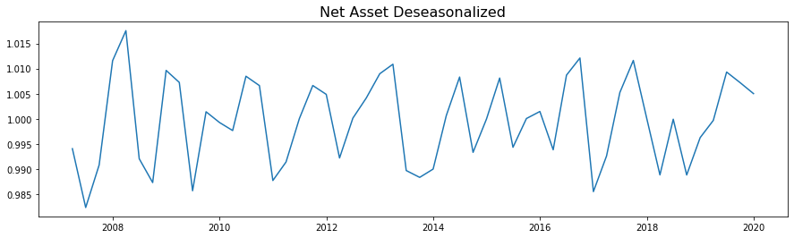

```python
# Time Series Decomposition

# result_mul = seasonal_decompose(dategroup.netasset, model='multiplicative', extrapolate_trend='freq')
result_mul = seasonal_decompose(detrended2, model='multiplicative', freq=4)
# Deseasonalize Net Asset
# deseasonalizedNet = detrended12.tolist() - result_mul.seasonal
deseasonalizedNet = detrended2.tolist() / result_mul.seasonal
# Plot
fig, ax = plt.subplots(1,figsize=(15,4),sharex=False)
plt.plot(deseasonalizedNet)
plt.title('Net Asset Deseasonalized', fontsize=16)
plt.plot()
```

```python
# ADF Test
print('\nNet Asset: Stationarity test 4')
result = adfuller(deseasonalizedNet, autolag='AIC')
print(f'ADF Statistic: {result[0]}')
print(f'p-value: {result[1]}')
for key, value in result[4].items():
    print('Critial Values:')
    print(f'   {key}, {value}')

# KPSS Test
result = kpss(deseasonalizedNet, regression='c')
print('\nKPSS Statistic: %f' % result[0])
print('p-value: %f' % result[1])
for key, value in result[3].items():
    print('Critial Values:')
    print(f'   {key}, {value}')
```

```
Net Asset: Stationarity test 4
ADF Statistic: -5.68669787980794
p-value: 8.247883312995936e-07
Critial Values:
   1%, -3.5745892596209488
Critial Values:
   5%, -2.9239543084490744
Critial Values:
   10%, -2.6000391840277777

KPSS Statistic: 0.220286
p-value: 0.100000
Critial Values:
   10%, 0.347
Critial Values:
   5%, 0.463
Critial Values:
   2.5%, 0.574
Critial Values:
   1%, 0.739
```

NetAsset has much improvement after deseasonalizing, and achieves more stationarity. This is consist with the cyclic pattern of NetAsset. Now we can use Net Asset for prediction.

### Autocorrelation & Partial Autocorrelation

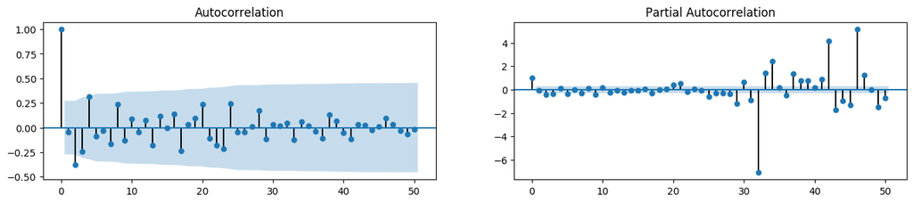

[figure not shown]

```python
# Net Asset after detrending
from statsmodels.tsa.stattools import acf, pacf
from statsmodels.graphics.tsaplots import plot_acf, plot_pacf

fig, axes = plt.subplots(1,2,figsize=(16,3), dpi= 100)
plot_acf(detrended2.tolist(), lags=50, ax=axes[0])
plot_pacf(detrended2.tolist(), lags=50, ax=axes[1])
```

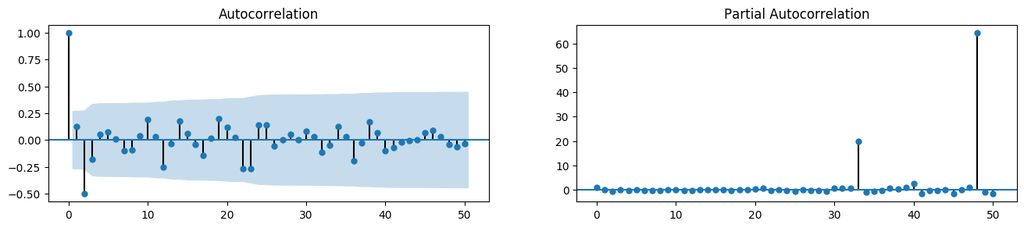

[figure not shown]

```python
# Net Asset after detrending and deseasonalizing
fig, axes = plt.subplots(1,2,figsize=(16,3), dpi= 100)
plot_acf(deseasonalizedNet.tolist(), lags=50, ax=axes[0])
plot_pacf(deseasonalizedNet.tolist(), lags=50, ax=axes[1])
```